# Table des Matieres

# Introduction

Ce notebook presente une analyse des donnees de pointage des employes, en se concentrant sur les absences et les retards par service et par direction. L'objectif est de fournir une vue claire des services et directions les plus touches par ces problemes, avec des graphiques pour illustrer les classements.

# Rapport d'Analyse des Donnees de Pointage

## Introduction

```
Le dataset couvre la période du 2024-05-24 00:00:00 au 2024-07-31 00:00:00.
```

## Analyse des Absences

Cette section presente les resultats de l'analyse des absences par service et par direction. Les graphiques montrent les services et les directions avec le plus grand nombre d'absences.

## Repartition Globale des Types de Journee

Cette section explore la repartition generale des types de journee, incluant les journees normales, les retards, les demi-journees, et les absences. Chaque type est represente par un graphique a barres, indiquant clairement le nombre d'employes pour chaque categorie.

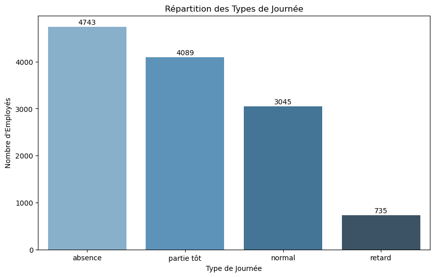

## Tendance Mensuelle des Presences et Retards

Ce graphique montre l'evolution des pointages par mois pour les differents types (presence normale, retard, absence, etc.). Cela nous permet d'identifier les mois ou il y a eu des pics d'absences ou de retards.

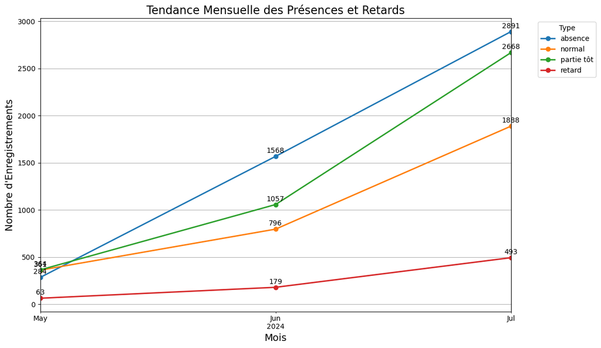

## Classement Complet des Employes Base sur les Retards

Dans cette section, nous classons tous les employes en fonction du nombre de retards accumules. Ce classement affiche le nom de l'employe, sa direction, son service, ainsi que le nombre total de retards.

| Nom | DIRECTION: | SERVICE: | Total_Retard |
| --- | --- | --- | --- |
| Maty SENGHOR | DGC | DNFONCTIONNAIRES | 42 |
| El Hadji DIOP | DGFP | dgfp | 38 |
| Ndeye Bineta | DGFP | VISA | 33 |
| Cheikh Mbaye NDIAYE | SG | courrier | 33 |
| Mamadou Cisse NGOM | DRSP | drsp | 28 |
| Astou MARIKO | DGC | DFONCTIONNAIRES | 24 |
| Ismaila SYLLA | DGC | DFONCTIONNAIRES | 24 |
| Koumbouna DIOUARA | DGC | dgc | 22 |
| Abdou Aziz FAYE | DGFP | VISA | 22 |
| Abdoulaye NDIAYE | DGC | DNFONCTIONNAIRES | 21 |
| Ababacar CISS | DGFP | VISA | 20 |
| Boubacar DIALLO | DAGE | dage | 19 |
| Bineta DIOUF | DGFP | VISA | 16 |
| Sokhna Faty MBACKE | DSI | DAQES | 16 |
| Sadio SOW | DAGE | DRH | 16 |
| Tidiane Baidy DIEYE | DGC | DENS | 15 |
| Ndeye Yaram NDIAYE | DSI | DAQES | 15 |
| Safietou Fatel Ngon DIALLO | DGFP | dgfp | 14 |
| Ndiouma FAYE | DGFP | dgfp | 14 |
| Sangone DIOP | DSI | DARSE | 13 |
| Mayéni GUEYE | SG | sg | 12 |
| Ibrahima DIOP | DSI | DAQES | 12 |
| Papa Tamsir DIOP | DGPEEC | dgpeec | 12 |
| Omar SALL | DAGE | dage | 10 |
| Dethie GNING | DELC | delc | 10 |
| Sokhna Lo FAYE | DGPEEC | dgpeec | 10 |
| Omar Marie NDAO | CABINET | SRPD | 9 |
| Awa DIOP | DGFP | dgfp | 9 |
| Ndeye Soda GUEYE | DELC | delc | 9 |
| Woulimata NDONG | DGC | dgc | 9 |

[output cut: 60 more lines]

## Classement Complet des Employes Base sur les Absences

Cette section presente le classement des employes en fonction du nombre d'absences. Pour chaque employe, vous trouverez son nom, sa direction, son service, ainsi que le nombre total d'absences enregistrees.

| Nom | DIRECTION: | SERVICE: | Total_Absence |
| --- | --- | --- | --- |
| Ismaila SYLLA | DGC | DFONCTIONNAIRES | 77 |
| Helene SOW | DGFP | dgfp | 69 |
| Cheikh Oumar SALL | DAGE | dage | 69 |
| Aida HANNE | DGC | dgc | 69 |
| Aicha Diaite | DGFP | VISA | 69 |
| El Hadji Yakhya SECK | DGFP | BLIAISON | 69 |
| Fatou Mbengue DIENE | DGC | dgc | 69 |
| Hamad FAYE | DELC | delc | 69 |
| Hamadou Bamba | DGFP | VISA | 69 |
| Khalidou SOKO | DGFP | VISA | 69 |
| Bassirou MBOUP | DGC | dgc | 69 |
| Mamadou Abdoulaye TOURE | DRSP | drsp | 69 |
| Mamadou NDIAYE | DGFP | dgfp | 69 |
| Mame Léna FALL | DGC | DNFONCTIONNAIRES | 69 |
| Moussa DIAGNE | DGFP | BLIAISON | 69 |
| Ndeye Amie NDAO | DGC | dgc | 69 |
| Serigne Mouhamadou Mbacke LO | SG | sg | 69 |
| Serigne Saliou KEBE | DGC | dgc | 69 |
| Bineta Sylla TALL | DGFP | VISA | 69 |
| bamba fall | DELC | DEL | 67 |
| Amadou Mactar CISSE | DGFP | dgfp | 66 |
| Mbaye Babacar DIOUF | SG | courrier | 66 |
| Top SOW | DGPEEC | dgpeec | 66 |
| Sounkarou DRAME | DGC | DFONCTIONNAIRES | 62 |
| Khalifa NDIAYE | DGC | DENS | 61 |
| Pierre Birame DIOH | CABINET | SRPD | 60 |
| Cheikh NDIAYE | DGC | dgc | 57 |
| Mass NIANG | DGPEEC | DFP | 56 |
| Aliou Mamadou DIALLO | DGFP | dgfp | 51 |
| Daouda WADE | DGFP | dgfp | 48 |

[output cut: 155 more lines]

Les classements ci-dessus vous montrent, dans un ordre decroissant, les employes avec le plus grand nombre de retards et d'absences. Chaque tableau presente les employes avec leur nom, leur direction, leur service, et le nombre total de retards ou d'absences.

## Liste des Employes Pointant Apres 8h

Cette section liste tous les employes ayant pointe apres 8 heures du matin. Nous calculons egalement le pourcentage d'employes qui arrivent apres cette heure, ce qui peut indiquer des habitudes de retard generalisees.

```
Pourcentage d'employés qui se présentent après 8 heures du matin : 85.41%
Les employés qui se présentent après 8 heures du matin :
```

| Nom | DIRECTION: | SERVICE: | Total_Checkins_After_8 |
| --- | --- | --- | --- |
| Cheikh Mbaye NDIAYE | SG | courrier | 66 |
| Omar SALL | DAGE | dage | 64 |
| Ndeye Awa NDIAYE | DGC | dgc | 62 |
| Mouhamed DIALLO | DGC | DPR | 62 |
| Ismaila SYLLA | DGC | DFONCTIONNAIRES | 61 |
| Alassane KANTE | DGC | DPR | 60 |
| Seynabou NDOYE | DGC | DPR | 60 |
| Abasse DIOUF | DGPEEC | dgpeec | 60 |
| Fatou Bintou DIA | DGFP | dgfp | 59 |
| Thierno KA | DGC | DPR | 59 |
| Mamadou SENE | DGC | DENS | 59 |
| Fatou DIAGNE | DGFP | VISA | 58 |
| Abdoulaye NDIAYE | DGC | DNFONCTIONNAIRES | 58 |
| El Hadji DIOP | DGFP | dgfp | 58 |
| Marie Ndélla DIOUF | DRSP | DMODERNISATION | 57 |
| Ndeye Bineta | DGFP | VISA | 57 |
| Papa Tamsir DIOP | DGPEEC | dgpeec | 57 |
| Mouhamadou Moustapha DIOP | DGC | dgc | 56 |
| Aïssatou FALL | DGPEEC | DS | 56 |
| Marieme Ndieune DIOUF | DGC | DPR | 56 |
| Ababacar CISS | DGFP | VISA | 56 |
| Tahirou DIOUF | DGC | DENS | 56 |
| Maty SENGHOR | DGC | DNFONCTIONNAIRES | 55 |
| Fatou Binetou SALL | DRSP | drsp | 55 |
| Sona SABALY | DSI | dsi | 55 |
| Boubacar DIALLO | DAGE | dage | 55 |
| Matou AMAR | DGC | dgc | 54 |
| Sangone DIOP | DSI | DARSE | 52 |
| Aminata Diagne LO | DELC | delc | 52 |
| Fatou CISSE | DGC | DENS | 52 |

[output cut: 128 more lines]

## Tendance Mensuelle des Absences

Le graphique ci-dessous montre la tendance mensuelle des absences, permettant de visualiser les mois ou les absences ont ete particulierement elevees.

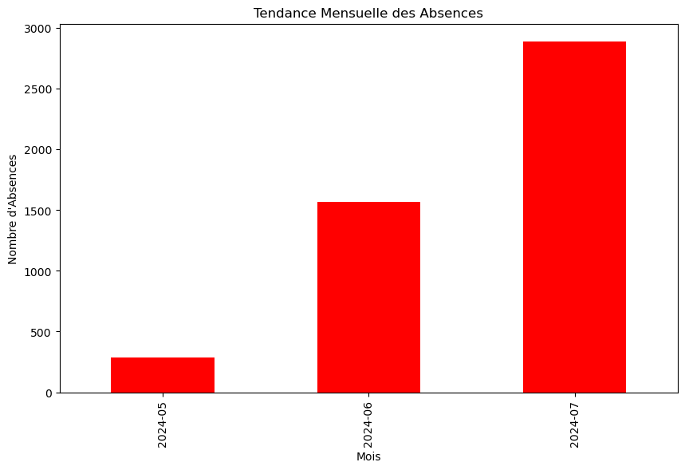

## Top 10 des Employes avec le Plus d'Absences par Direction

Dans cette analyse, nous avons classe les 10 employes ayant le plus d'absences pour chaque direction. Cela permet d'identifier les employes qui ont le plus manque de jours de travail, en se basant sur le nombre d'absences enregistrees.

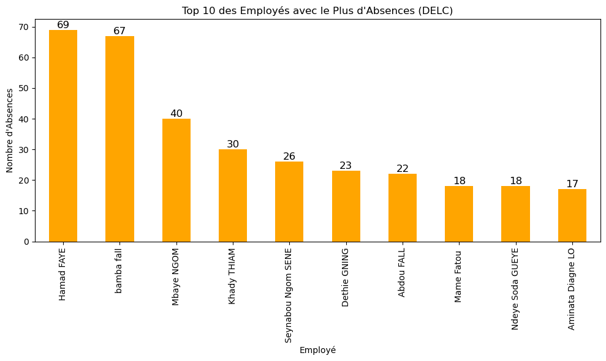

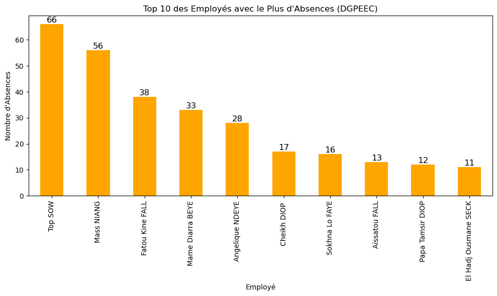

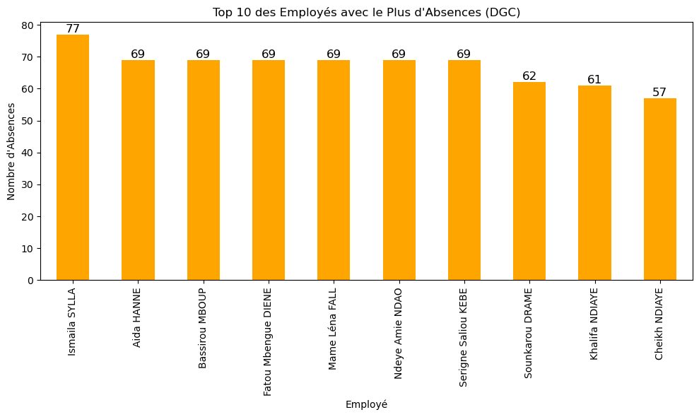

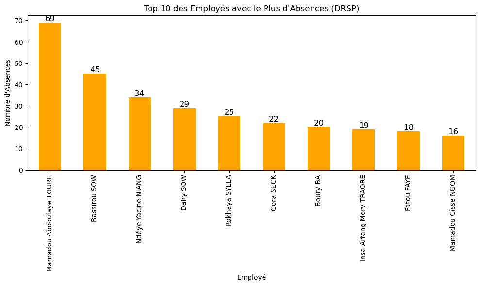

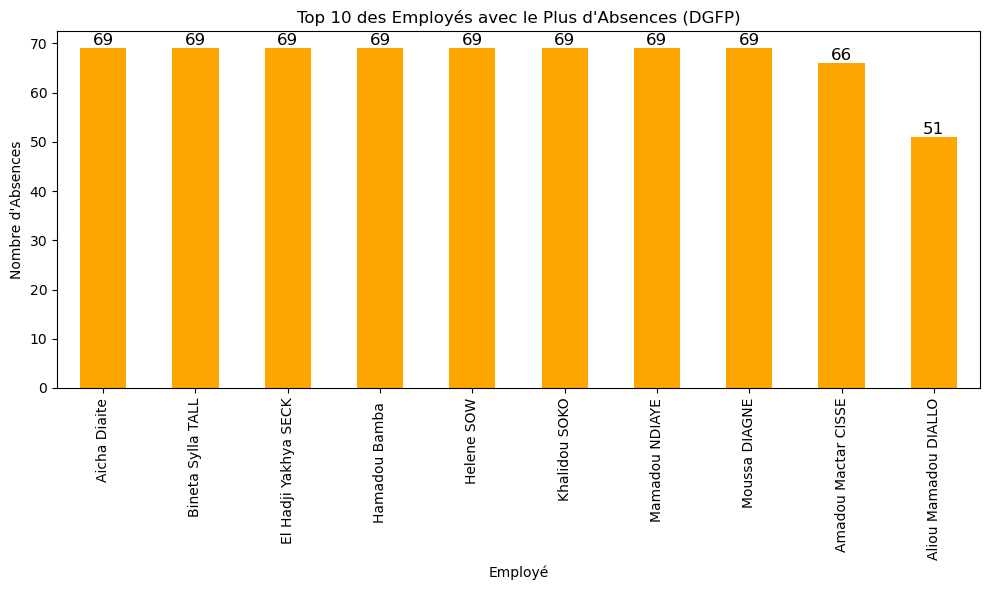

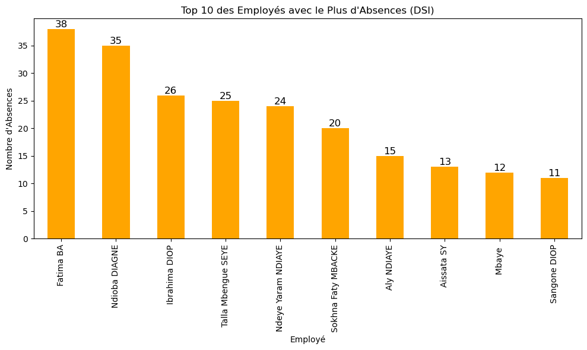

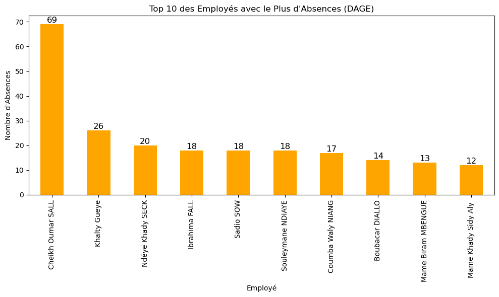

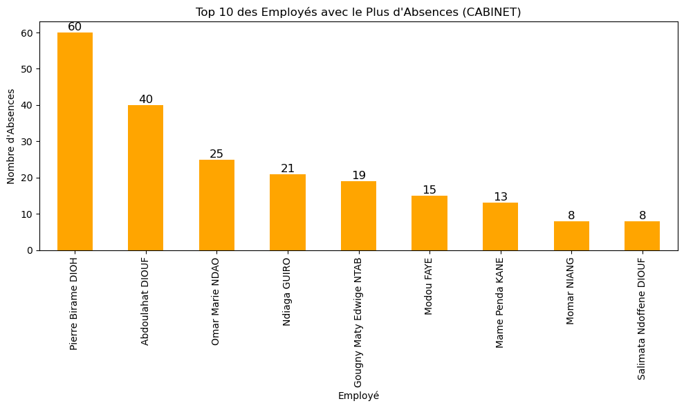

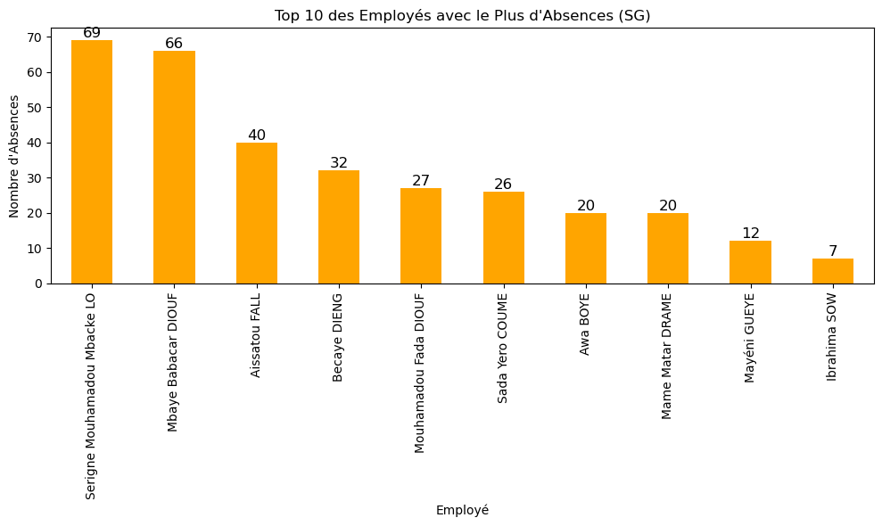

## Top 10 des Employes avec le Plus de Retards par Direction

Dans cette analyse, nous avons classe les dix employes ayant le plus de retards pour chaque direction. Cela permet d'identifier les employes qui arrivent le plus souvent en retard au travail, en se basant sur le nombre de retards enregistres.

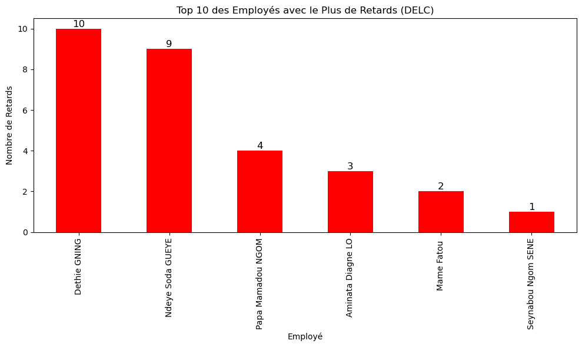

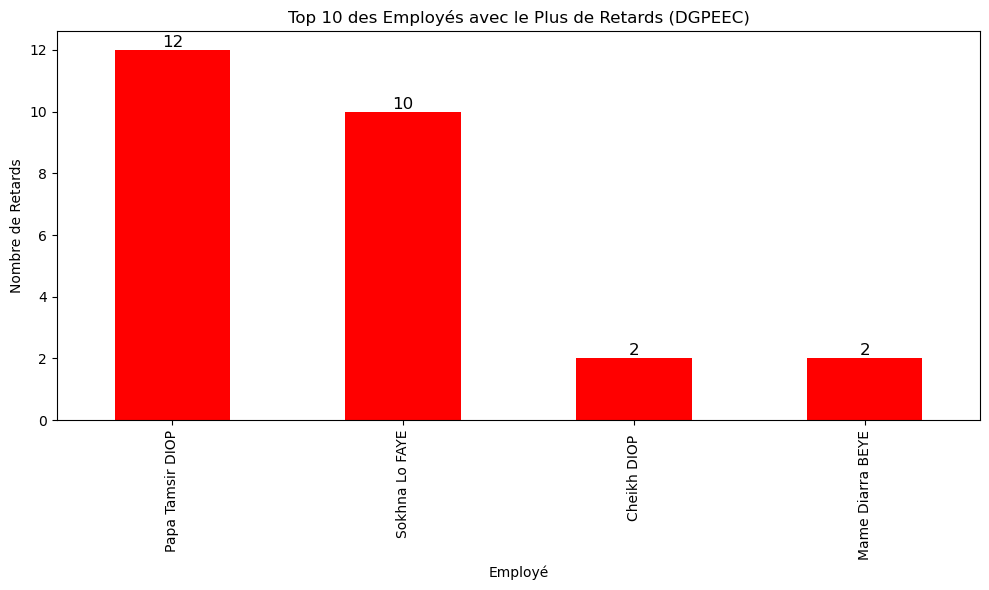

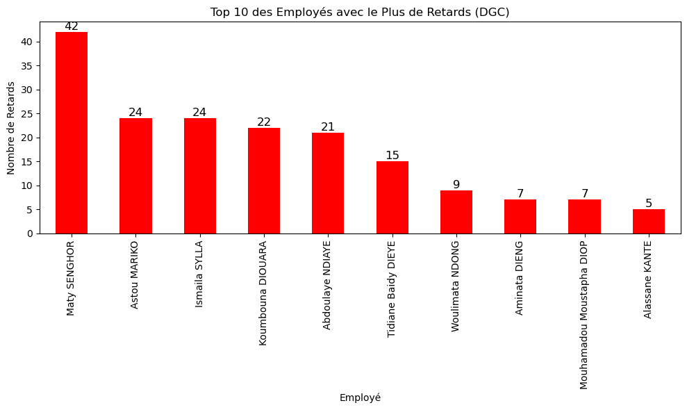

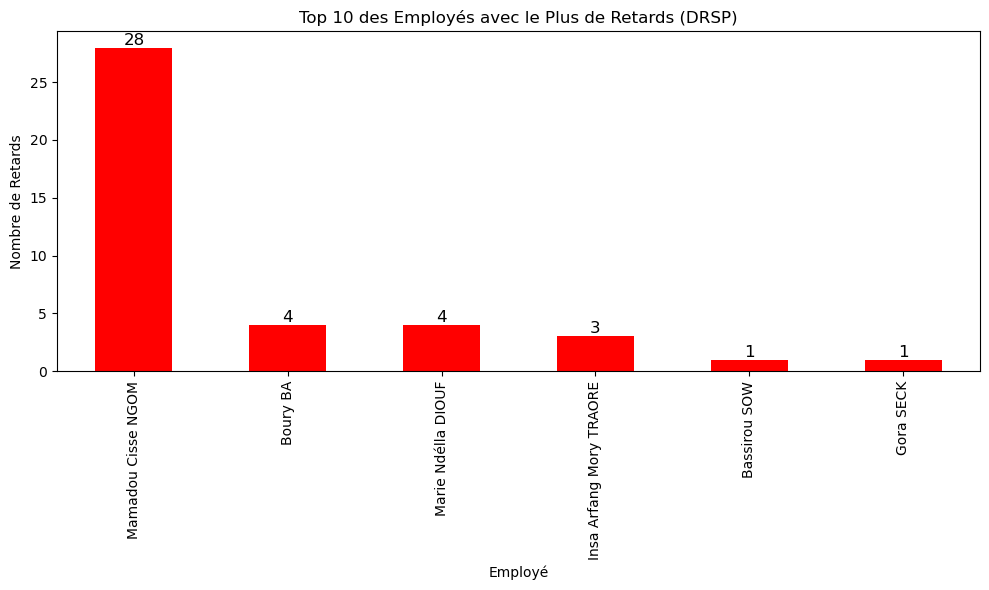

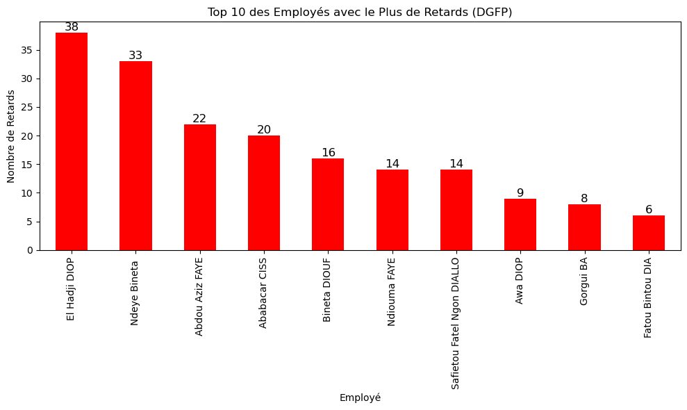

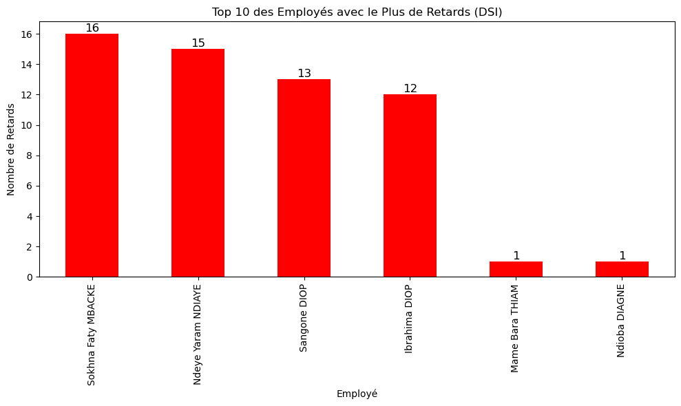

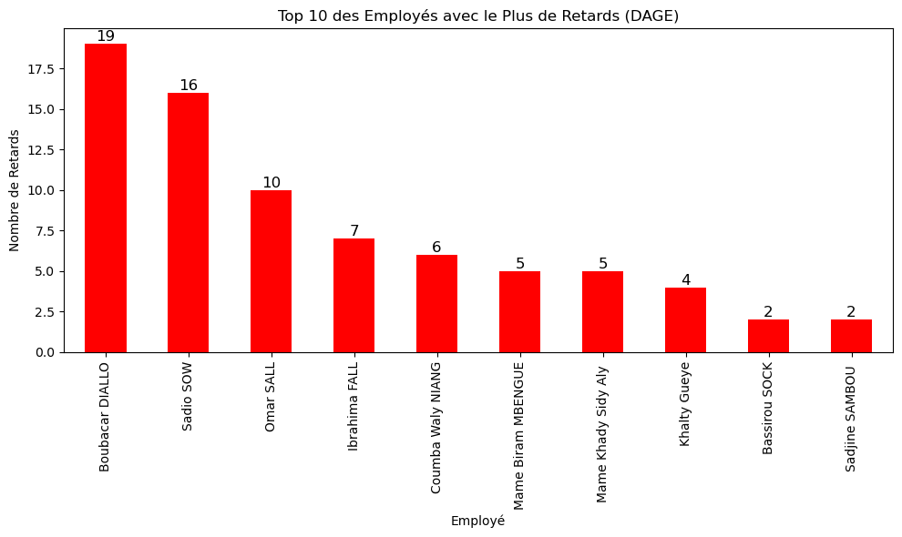

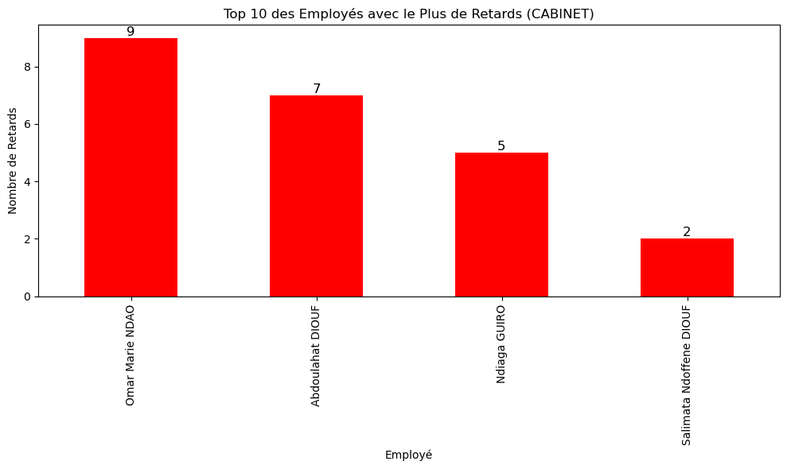

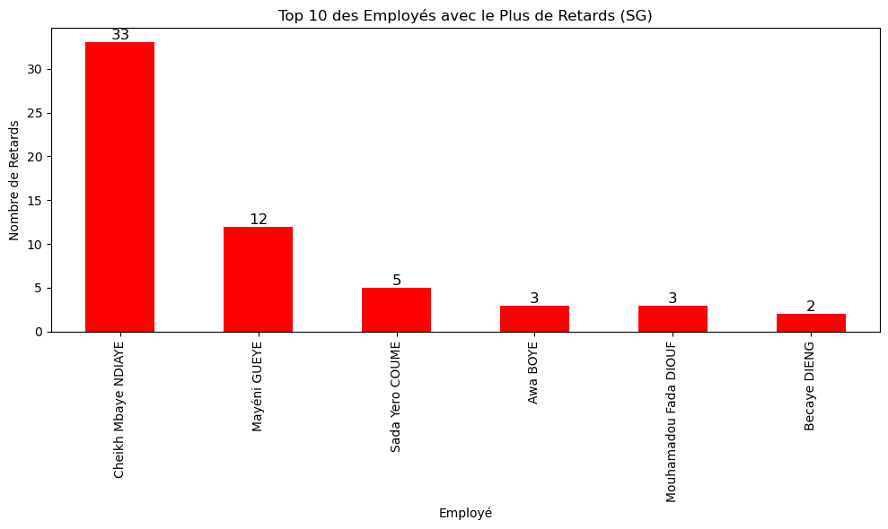

## Classement Graphique des Services avec le Plus d'Absences

Ce graphique montre les dix services ayant accumule le plus grand nombre d'absences. Cela permet d'identifier les services les plus touches par l'absenteisme.

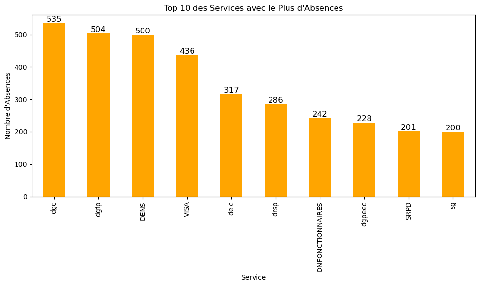

## Classement Graphique des Directions avec le Plus d'Absences

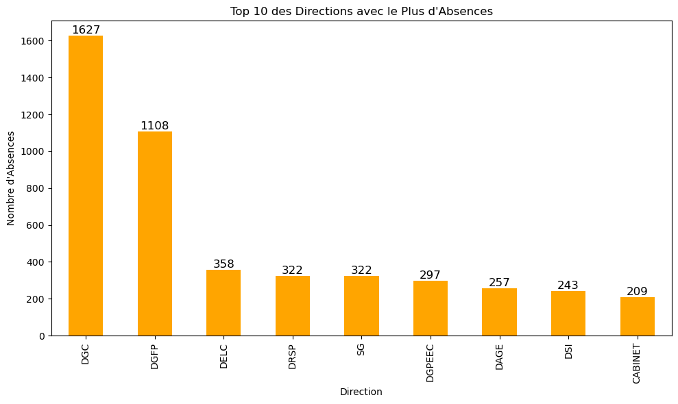

## Analyse des Retards

Une analyse specifique des retards est realisee par service pour identifier les services les plus touches.

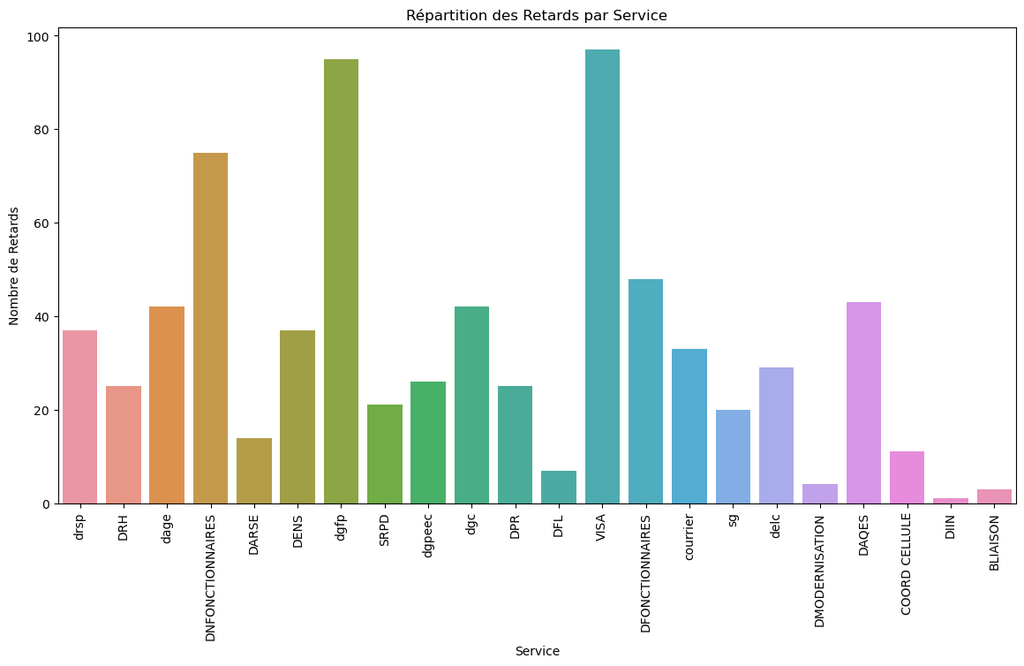

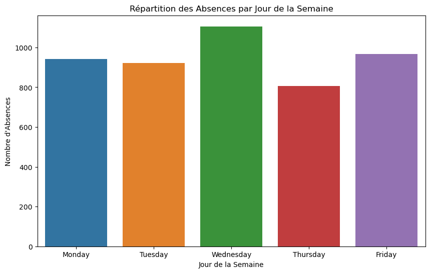

**Temps de Presence Moyen par Jour de la Semaine** : Ce graphique montre les jours ou les employes sont les plus presents au bureau.

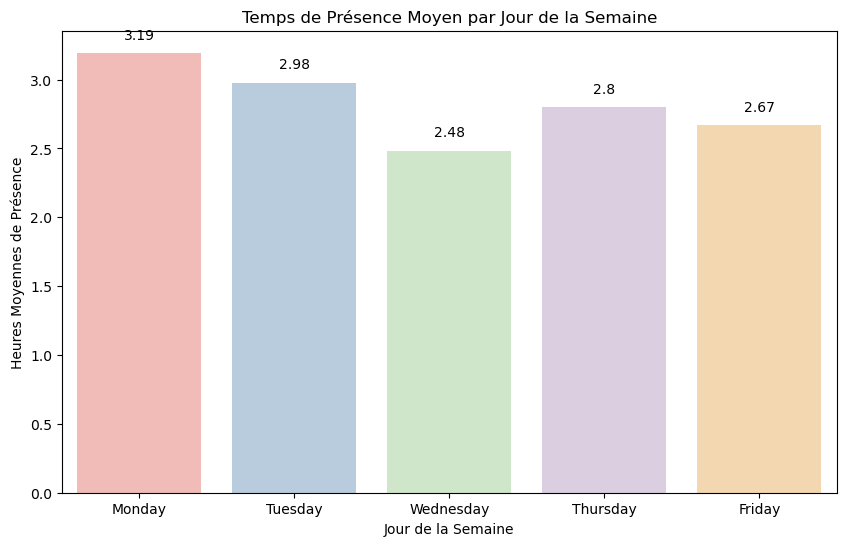

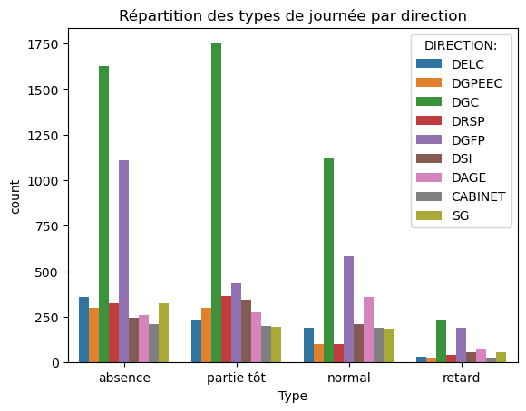

## Analyse par Heure d'Entree et de Sortie

Explorer les heures d'entree et de sortie pour voir s'il y a des pics specifiques, ce qui pourrait indiquer des periodes de pointe pour les arrivees ou les departs.

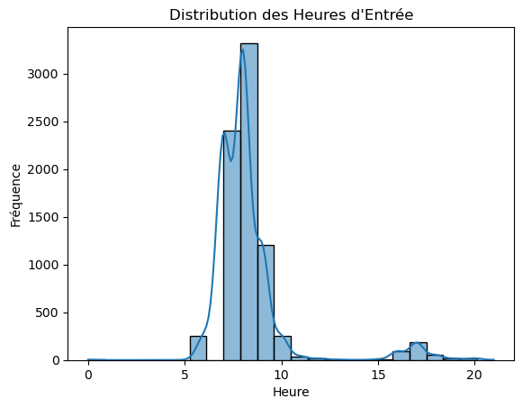

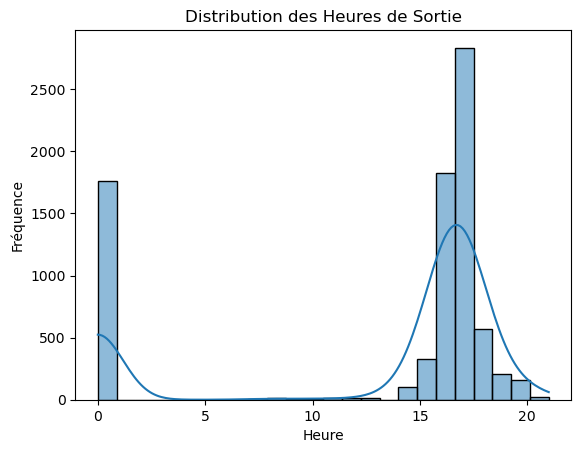

## Conclusion

Ces analyses peuvent guider des decisions manageriales eclairees, comme l'ajustement des horaires, la mise en place de mesures incitatives, ou le renforcement des politiques de ponctualite.

Les visualisations proposees permettent de rendre les donnees accessibles a un public non technique, facilitant ainsi la comprehension et l'appropriation des resultats.